# Non-probability-based Surveys in Practice

## 3.3) Plot distribution of estimation-benchmark differences

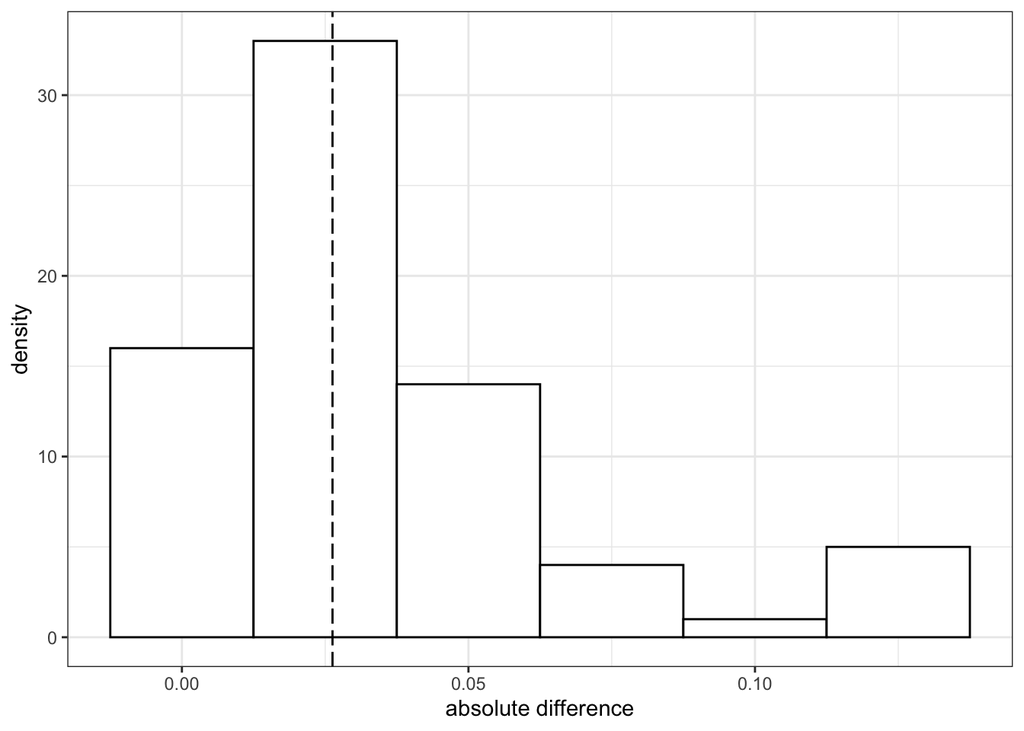

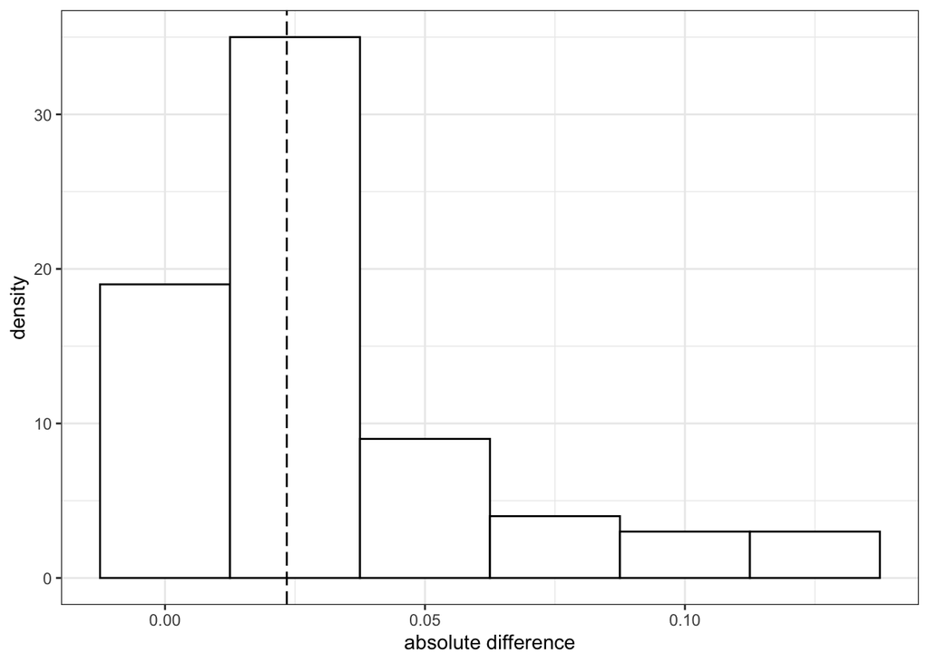

# Approach 4: Model-based estimation with post-stratification

## 4.1) Predict group means with simple regression model; combine with group weights to create weighted means

## 4.2) Plot estimated means against benchmarks

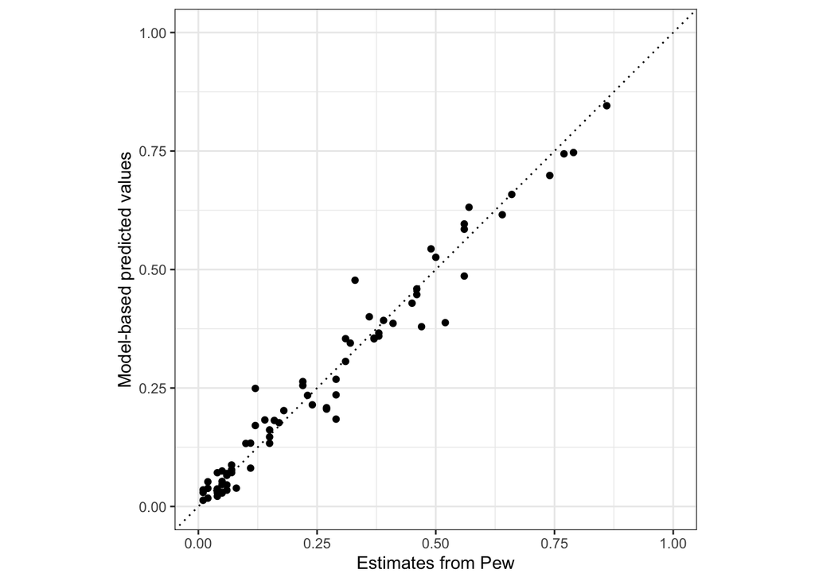

## 4.3) Plot distribution of estimation-benchmark differences

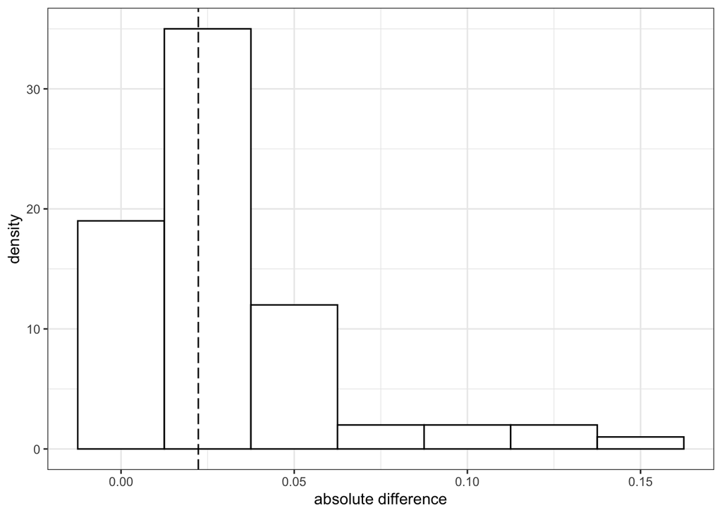

# Compare distribution of differences across methods and questions

Which questions worked well and which didn’t? Which methods worked well for which questions?

Note: If you used the simulated data, differences may not be large. The reason is that these were simulated on the population estimates, so they do not differ much in the first place.

[^1]: based on the activities from SICSS 2019 (Matthew Salganik and Cambria Naslund).